# practical-Machine-Learning

Kaushik Prasad Dey

8/11/2022

## Introduction

Using devices such as Jawbone Up, Nike FuelBand, and Fitbit it is now possible to collect a large amount of data about personal activity relatively inexpensively. These type of devices are part of the quantified self movement – a group of enthusiasts who take measurements about themselves regularly to improve their health, to find patterns in their behavior, or because they are tech geeks. One thing that people regularly do is quantify how much of a particular activity they do, but they rarely quantify how well they do it.

In this project, we will use data from accelerometers on the belt, forearm, arm, and dumbell of 6 participants to predict the manner in which they did the exercise.

## Added Required Libraries

```r
library(caret)
```

```r
library(rpart)
library(rpart.plot)
library(randomForest)
library(corrplot)
```

## Download the Data

```r
trainUrl <-"https://d396qusza40orc.cloudfront.net/predmachlearn/pml-training.csv"
testUrl <- "https://d396qusza40orc.cloudfront.net/predmachlearn/pml-testing.csv"
trainFile <- "./coursera_practical_Learning_project/pml-training.csv"
testFile  <- "./coursera_practical_Learning_project/pml-testing.csv"
if (!file.exists("./coursera_practical_Learning_project")) {
  dir.create("./coursera_practical_Learning_project")
}
if (!file.exists(trainFile)) {
  download.file(trainUrl, destfile=trainFile, method="curl")
}
if (!file.exists(testFile)) {
  download.file(testUrl, destfile=testFile, method="curl")
}
```

## Read the Data

```r
train_raw_data <- read.csv("./coursera_practical_Learning_project/pml-training.csv")
test_raw_data <- read.csv("./coursera_practical_Learning_project/pml-testing.csv")
dim(train_raw_data)
```

```
## [1] 19622   160
```

```r
dim(test_raw_data)
```

```
## [1]  20 160
```

The training data set contains 19622 observations and 160 variables, while the testing data set contains 20 observations and 160 variables. The “classe” variable in the training set is the outcome to predict.

# Clean the data

In this step, we will clean the data and get rid of observations with missing values as well as some meaningless variables.

```r
sum(complete.cases(train_raw_data))
```

```
## [1] 406
```

## First, we remove columns that contain NA missing values.

```r
train_raw_data <- train_raw_data[, colSums(is.na(train_raw_data)) == 0]
test_raw_data <- test_raw_data[, colSums(is.na(test_raw_data)) == 0]
summary(train_raw_data)
```

[output not shown]

[output cut: 145 more lines]

```
##  Min.   :-632.0   Min.   :-446.00   Min.   :-1280.0   Min.   :-896.0
##  1st Qu.:  57.0   1st Qu.:-182.00   1st Qu.: -616.0   1st Qu.:   2.0
##  Median : 201.0   Median : -39.00   Median : -378.0   Median : 591.0
##  Mean   : 163.7   Mean   : -55.29   Mean   : -312.6   Mean   : 380.1
##  3rd Qu.: 312.0   3rd Qu.:  26.00   3rd Qu.:  -73.0   3rd Qu.: 737.0
##  Max.   : 923.0   Max.   : 291.00   Max.   :  672.0   Max.   :1480.0
##
##  magnet_forearm_z classe
##  Min.   :-973.0   A:5580
##  1st Qu.: 191.0   B:3797
##  Median : 511.0   C:3422
##  Mean   : 393.6   D:3216
##  3rd Qu.: 653.0   E:3607
##  Max.   :1090.0
##
```

```r
summary(test_raw_data)
```

[output not shown]

[output cut: 65 more lines]

```
##  Min.   :-1.2600   Min.   :-212.0   Min.   :-331.0   Min.   :-282.0
##  1st Qu.:-0.0975   1st Qu.:-114.8   1st Qu.:   8.5   1st Qu.:-199.0
##  Median : 0.2300   Median :  86.0   Median : 138.0   Median :-148.5
##  Mean   : 0.2610   Mean   :  38.8   Mean   : 125.3   Mean   : -93.7
##  3rd Qu.: 0.7625   3rd Qu.: 166.2   3rd Qu.: 268.0   3rd Qu.: -31.0
##  Max.   : 1.8000   Max.   : 232.0   Max.   : 406.0   Max.   : 179.0
##
##  magnet_forearm_x magnet_forearm_y magnet_forearm_z   problem_id
##  Min.   :-714.0   Min.   :-787.0   Min.   :-32.0    Min.   : 1.00
##  1st Qu.:-427.2   1st Qu.:-328.8   1st Qu.:275.2    1st Qu.: 5.75
##  Median :-189.5   Median : 487.0   Median :491.5    Median :10.50
##  Mean   :-159.2   Mean   : 191.8   Mean   :460.2    Mean   :10.50
##  3rd Qu.:  41.5   3rd Qu.: 720.8   3rd Qu.:661.5    3rd Qu.:15.25
##  Max.   : 532.0   Max.   : 800.0   Max.   :884.0    Max.   :20.00
##
```

Next, we get rid of some columns that do not contribute much to the accelerometer measurements.

```r
classe <- train_raw_data$classe
trainRemove <- grepl("^X|timestamp|window", names(train_raw_data))
train_raw_data <- train_raw_data[, !trainRemove]
trainCleaned <- train_raw_data[, sapply(train_raw_data, is.numeric)]
trainCleaned$classe <- classe

testRemove <- grepl("^X|timestamp|window", names(test_raw_data))
test_raw_data <- test_raw_data[, !testRemove]
testCleaned <- test_raw_data[, sapply(test_raw_data, is.numeric)]
dim(trainCleaned)
```

```
## [1] 19622    53
```

```r
dim(testCleaned)
```

```
## [1] 20 53
```

Now, the cleaned training data set contains **(19622)** observations and **(53)** variables, while the testing data set contains **(20)** observations and **(53)** variables. The “classe” variable is still in the cleaned training set.

# Train & test split the data

Then, we can split the cleaned training set into a pure training data set **(70%)** and a validation data set **(30%)**. We will use the validation data set to conduct cross validation in future steps.

```r
set.seed(22519) # For reproducibile purpose
inTrain <- createDataPartition(trainCleaned$classe, p=0.70, list=F)
trainDataset <- trainCleaned[inTrain, ]
testDataset <- trainCleaned[-inTrain, ]
dim(trainDataset)
```

```
## [1] 13737    53
```

```r
dim(testDataset)
```

```
## [1] 5885   53
```

# Data Modeling

We fit a predictive model for activity recognition using **Random Forest** algorithm because it automatically selects important variables and is robust to correlated covariates & outliers in general. We will use **5-fold cross validation** when applying the algorithm.

```r
controlRf <- trainControl(method="cv", 5)
modelRf <- train(classe ~ ., data=trainDataset, method="rf", trControl=controlRf, ntree=250)
modelRf
```

```
## Random Forest
##
## 13737 samples
##    52 predictor
##     5 classes: 'A', 'B', 'C', 'D', 'E'
##
## No pre-processing
## Resampling: Cross-Validated (5 fold)
## Summary of sample sizes: 10988, 10989, 10989, 10991, 10991
## Resampling results across tuning parameters:
##
##   mtry  Accuracy   Kappa
##    2    0.9912654  0.9889499
##   27    0.9916291  0.9894104
##   52    0.9842766  0.9801110
##
## Accuracy was used to select the optimal model using the largest value.
## The final value used for the model was mtry = 27.
```

Then, we estimate the performance of the model on the validation data set.

```r
predictRf <- predict(modelRf, testDataset)
confusionMatrix(testDataset$classe, predictRf)
```

```
## Confusion Matrix and Statistics
##
##           Reference
## Prediction    A    B    C    D    E
##          A 1669    2    3    0    0
##          B    5 1130    3    1    0
##          C    0    4 1019    3    0
##          D    0    0   10  954    0
##          E    0    0    4    2 1076
##
## Overall Statistics
##
##                Accuracy : 0.9937
##                  95% CI : (0.9913, 0.9956)
##     No Information Rate : 0.2845
##     P-Value [Acc > NIR] : < 2.2e-16
##
##                   Kappa : 0.992
##
##  Mcnemar's Test P-Value : NA
##
## Statistics by Class:
##
##                      Class: A Class: B Class: C Class: D Class: E
## Sensitivity            0.9970   0.9947   0.9808   0.9938   1.0000
## Specificity            0.9988   0.9981   0.9986   0.9980   0.9988
## Pos Pred Value         0.9970   0.9921   0.9932   0.9896   0.9945
## Neg Pred Value         0.9988   0.9987   0.9959   0.9988   1.0000
## Prevalence             0.2845   0.1930   0.1766   0.1631   0.1828
## Detection Rate         0.2836   0.1920   0.1732   0.1621   0.1828
## Detection Prevalence   0.2845   0.1935   0.1743   0.1638   0.1839
## Balanced Accuracy      0.9979   0.9964   0.9897   0.9959   0.9994
```

# Find out the Accuracy

```r
accuracy <- postResample(predictRf, testDataset$classe)
accuracy
```

```
##  Accuracy     Kappa
## 0.9937128 0.9920477
```

```r
oose <- 1 - as.numeric(confusionMatrix(testDataset$classe, predictRf)$overall[1])
oose
```

```
## [1] 0.006287171
```

# Predicting for Test Data Set

Now, we apply the model to the **original testing data** set downloaded from the data source. **We remove the problem_id column first** .

```r
result <- predict(modelRf, testCleaned[, -length(names(testCleaned))])
result
```

```
##  [1] B A B A A E D B A A B C B A E E A B B B
## Levels: A B C D E
```

# Appendix: Figures

## 1.Correlation Matrix Visualization

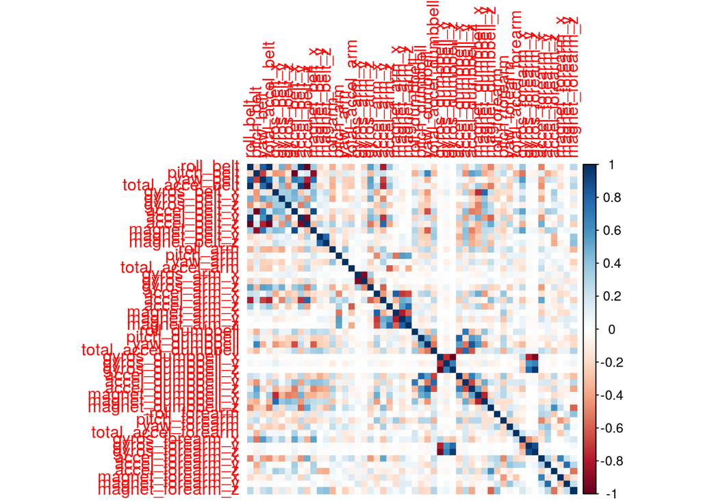

```r
corrPlot <- cor(trainDataset[, -length(names(trainDataset))])
corrplot(corrPlot, method="color")
```

## 2.Decision Tree Visualization

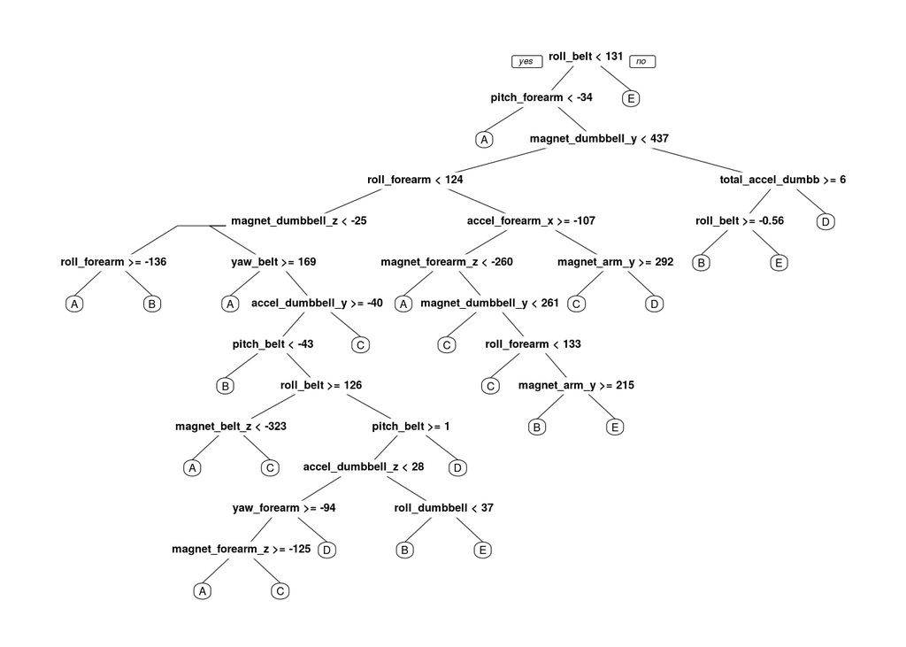

```r
treeModel <- rpart(classe ~ ., data=trainDataset, method="class")
prp(treeModel) # Creating fast plot
```